# Formatting ggplots key

John Shorter

Feb/21/2024

# Load packages

You might need to install some of these packages

```r
library(ggplot2)
library(tidyr)
library(dplyr)
library(readr)
library(readxl)
```

# Exercise - Now time for you to try

Let’s use the R built-in dataset CO2 as example: Ref: Potvin, C., Lechowicz, M. J. and Tardif, S. (1990), Ecology, 71, 1389–1400.

```r
head(CO2)
```

```
##   Plant   Type  Treatment conc uptake
## 1   Qn1 Quebec nonchilled   95   16.0
## 2   Qn1 Quebec nonchilled  175   30.4
## 3   Qn1 Quebec nonchilled  250   34.8
## 4   Qn1 Quebec nonchilled  350   37.2
## 5   Qn1 Quebec nonchilled  500   35.3
## 6   Qn1 Quebec nonchilled  675   39.2
```

```r
str(CO2)
```

```
## Classes 'nfnGroupedData', 'nfGroupedData', 'groupedData' and 'data.frame':   84 obs. of  5 variables:
##  $ Plant    : Ord.factor w/ 12 levels "Qn1"<"Qn2"<"Qn3"<..: 1 1 1 1 1 1 1 2 2 2 ...
##  $ Type     : Factor w/ 2 levels "Quebec","Mississippi": 1 1 1 1 1 1 1 1 1 1 ...
##  $ Treatment: Factor w/ 2 levels "nonchilled","chilled": 1 1 1 1 1 1 1 1 1 1 ...
##  $ conc     : num  95 175 250 350 500 675 1000 95 175 250 ...
##  $ uptake   : num  16 30.4 34.8 37.2 35.3 39.2 39.7 13.6 27.3 37.1 ...
##  - attr(*, "formula")=Class 'formula'  language uptake ~ conc | Plant
##   .. ..- attr(*, ".Environment")=<environment: R_EmptyEnv>
##  - attr(*, "outer")=Class 'formula'  language ~Treatment * Type
##   .. ..- attr(*, ".Environment")=<environment: R_EmptyEnv>
##  - attr(*, "labels")=List of 2
##   ..$ x: chr "Ambient carbon dioxide concentration"
##   ..$ y: chr "CO2 uptake rate"
##  - attr(*, "units")=List of 2
##   ..$ x: chr "(uL/L)"
##   ..$ y: chr "(umol/m^2 s)"
```

Task: produce a plot that includes the info for Type and Treatment, with uptake on Y axis. Let’s say we are interested in the effect of “Treatment” in each Type.

Hint:

1. What should be on the x axis?
2. What variable do you color or fill with?
3. What faceting layout do you want to use?

Now try to make the best plot you can!

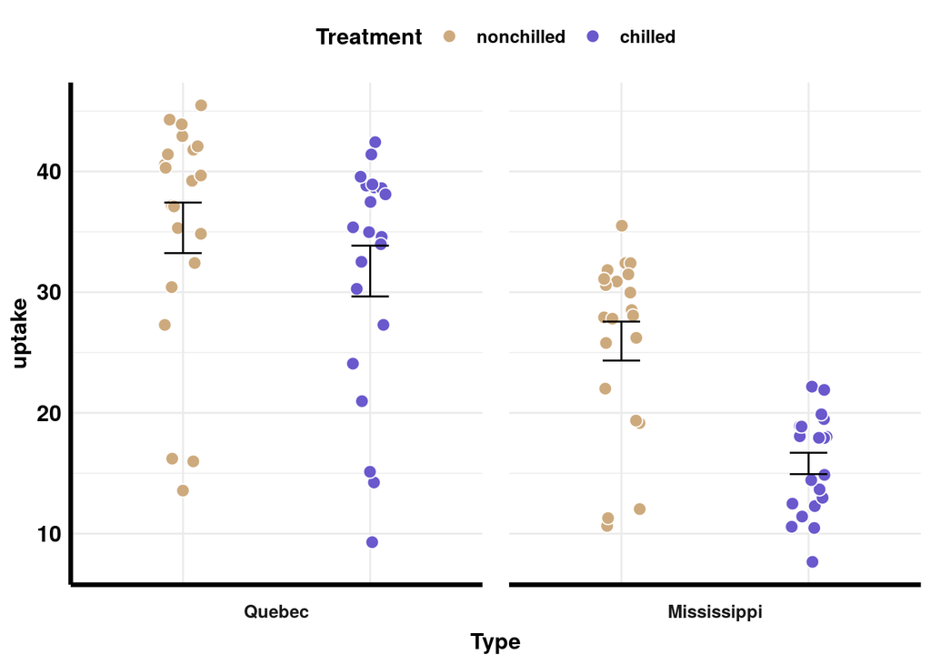

```r
CO2 %>%
  ggplot(aes(x = Treatment, y = uptake)) +
  facet_grid(. ~ Type, switch = "x") +
  geom_point(aes(fill = Treatment), size = 3, color = "white", shape = 21,
             position = position_jitter(0.1, seed = 666)) +
  stat_summary(geom = "errorbar", fun.data = mean_se, width = 0.2) +
  scale_fill_manual(values = c("burlywood3", "slateblue3"),
                    limits = c("nonchilled", "chilled")) +
  labs(x = "Type") +
  theme_minimal()+
  theme(legend.position = "top",
        axis.line = element_line(size = 1.2),
        panel.spacing.x = unit(1, "lines"),
        text = element_text(size = 12, color = "black", face = "bold"),
        axis.text.x = element_blank(),
        axis.text = element_text(size = 12, color = "black", face = "bold"),
        strip.placement = "outside"
        )
```

# Exercise 2 - Something fun!

Let’s use the Pokemon data set from https://www.kaggle.com/datasets/abcsds/pokemon?resource=download.

```r
Pokemon <- read.csv("/work/Data/Rmodule_data/Pokemon.csv", stringsAsFactors = FALSE)

Pokemon2 <- subset(Pokemon, Type.1 =='Water' | Type.1 =='Fire'| Type.1 =='Grass')
Pokemon2 <- subset(Pokemon2, Generation =='1' | Generation == '2')
#Don't worry about subsetting for now, we will go over this in a later lesson.
```

```r
head(Pokemon2)
```

```
##   X.                  Name Type.1 Type.2 Total HP Attack Defense Sp..Atk
## 1  1             Bulbasaur  Grass Poison   318 45     49      49      65
## 2  2               Ivysaur  Grass Poison   405 60     62      63      80
## 3  3              Venusaur  Grass Poison   525 80     82      83     100
## 4  3 VenusaurMega Venusaur  Grass Poison   625 80    100     123     122
## 5  4            Charmander   Fire          309 39     52      43      60
## 6  5            Charmeleon   Fire          405 58     64      58      80
##   Sp..Def Speed Generation Legendary
## 1      65    45          1     FALSE
## 2      80    60          1     FALSE
## 3     100    80          1     FALSE
## 4     120    80          1     FALSE
## 5      50    65          1     FALSE
## 6      65    80          1     FALSE
```

```r
str(Pokemon2)
```

```
## 'data.frame':    93 obs. of  13 variables:
##  $ X.        : int  1 2 3 3 4 5 6 6 6 7 ...
##  $ Name      : chr  "Bulbasaur" "Ivysaur" "Venusaur" "VenusaurMega Venusaur" ...
##  $ Type.1    : chr  "Grass" "Grass" "Grass" "Grass" ...
##  $ Type.2    : chr  "Poison" "Poison" "Poison" "Poison" ...
##  $ Total     : int  318 405 525 625 309 405 534 634 634 314 ...
##  $ HP        : int  45 60 80 80 39 58 78 78 78 44 ...
##  $ Attack    : int  49 62 82 100 52 64 84 130 104 48 ...
##  $ Defense   : int  49 63 83 123 43 58 78 111 78 65 ...
##  $ Sp..Atk   : int  65 80 100 122 60 80 109 130 159 50 ...
##  $ Sp..Def   : int  65 80 100 120 50 65 85 85 115 64 ...
##  $ Speed     : int  45 60 80 80 65 80 100 100 100 43 ...
##  $ Generation: int  1 1 1 1 1 1 1 1 1 1 ...
##  $ Legendary : logi  FALSE FALSE FALSE FALSE FALSE FALSE ...
```

Task: produce a plot that compares speed of fire, grass, and water pokemon from generations 1 and 2. Let’s keep it simple and use only the primary type. (Type.1 column)

Hint:

1. What should be on the x axis?
2. What variable do you color or fill with?
3. What faceting layout do you want to use?

Now try to make the best plot you can!

Which type is the fastest? Which pokemon is the fastest?

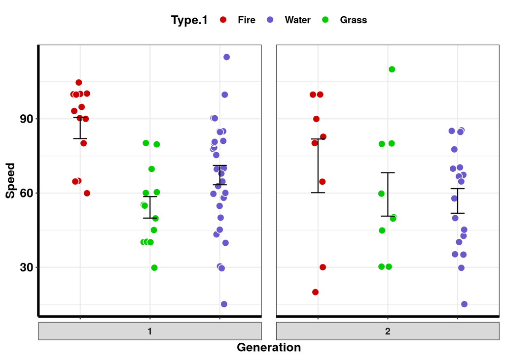

```r
Pokemon2 %>%
  ggplot(aes(x = Type.1, y = Speed)) +
  facet_grid(. ~ Generation, switch = "x") +
  geom_point(aes(fill = Type.1), size = 3, color = "white", shape = 21,
             position = position_jitter(0.1, seed = 666)) +
  stat_summary(geom = "errorbar", fun.data = mean_se, width = 0.2) +
  scale_fill_manual(values = c("red3", "slateblue3", "green3"),
                    limits = c("Fire", "Water", "Grass")) +
  labs(x = "Generation") +
  theme_bw()+
  theme(legend.position = "top",
        axis.line = element_line(size = 1.2),
        panel.spacing.x = unit(1, "lines"),
        text = element_text(size = 12, color = "black", face = "bold"),
        axis.text.x = element_blank(),
        axis.text = element_text(size = 12, color = "black", face = "bold"),
        strip.placement = "outside"
        )
```